# ACCESS-OM2 & Bash Tips and Tricks

# 28 How to delete branch locally and remotely with git

```
// delete branch locally
git branch -d localBranchName

// delete branch remotely
git push origin --delete remoteBranchName
```

# 29 How to locate ERA5 data on Gadi

For example here the 2 meter surface air temperature values:

```
t2m = xr.open_dataset('/g/data/ub4/era5/netcdf/land/t2m/2019/t2m_era5land_global_20191201_20191231.nc').t2m
t2m = t2m.sel(time='2019-12-19').mean('time') - 273.15
t2m.plot()
plt.savefig(save + 'era5_t2m_20191219', dpi=300, facecolor='w',
            edgecolor='w', orientation='landscape', papertype=None,
            format=None, transparent=False, bbox_inches='tight',
            pad_inches=0.1, metadata=None)
# Wall time: 7.48 s
```

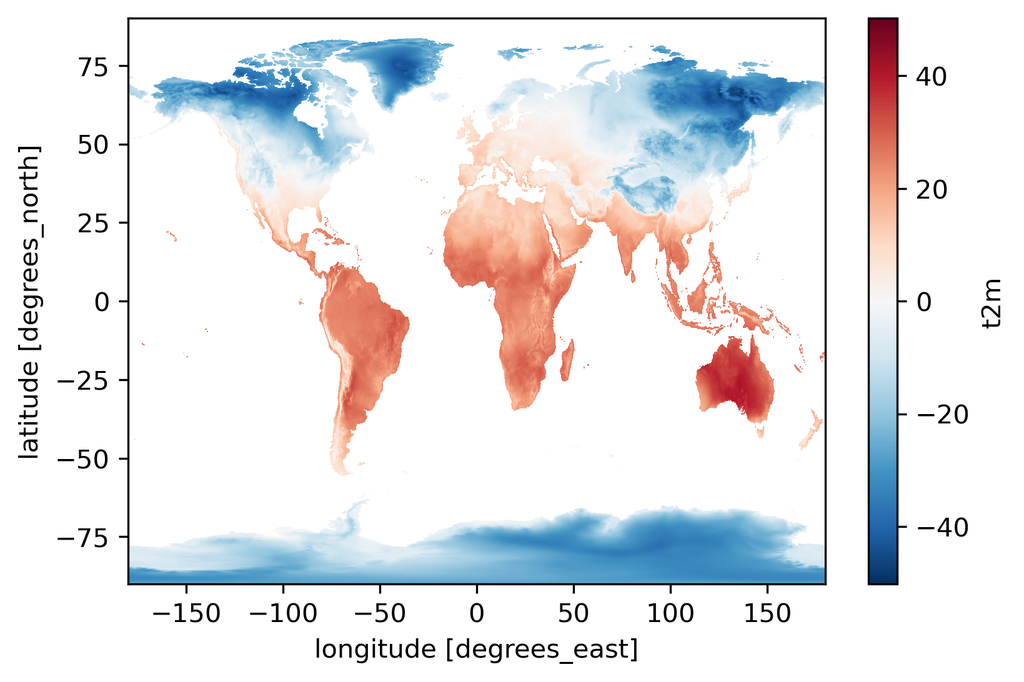

# 30 How to create the linear trend in a netcdf file (for example in JRA55-do’s SAT files)

```
cdo -detrend -selyear,1972/2018 -yearmean -mergetime ifile.nc ofile.nc
cdo yseassub ifile.nc -yseasavg ifile.nc ofile.nc
cdo trend ifile.nc intercept.nc trend.nc
```

# 31 Citations in the AGU LaTeX template

`\cite{kiss2019access}` -> (Kiss et al., 2019)

`\citeA{kiss2019access}` -> Kiss et al. (2019)

`\cite<KPP,>{large1994oceanic}` -> (KPP, Large et al., 1994)

# 32 Rotblau Colorbar in Python

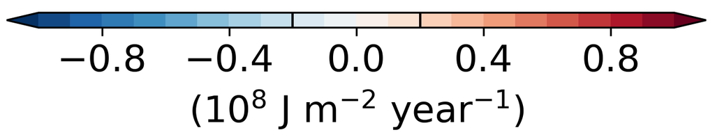

```
rotblau = [[0.4 , 0.  , 0.12], [0.47, 0.02, 0.13], [0.62, 0.07, 0.16], [0.66, 0.16, 0.2],
           [0.8 , 0.3 , 0.27], [0.87, 0.44, 0.35], [0.93, 0.58, 0.45], [0.96, 0.7 , 0.58],
           [0.98, 0.8 , 0.71], [0.98, 0.94, 0.92], [0.93, 0.95, 0.96], [0.85, 0.91, 0.95],
           [0.76, 0.87, 0.93], [0.64, 0.8 , 0.89], [0.49, 0.72, 0.84], [0.34, 0.62, 0.79],
           [0.23, 0.53, 0.74], [0.16, 0.44, 0.7] , [0.1 ,0.35, 0.6], [0.05, 0.24, 0.45],
           [0.02, 0.19, 0.38]]
```

# 33 Scientific Notation in R

`print(3.5e23/6.3e13, dig=3)` gives the result with exponent The values here represent the total ocean heat uptake 1971-2018 (J) divided by the energy of one Hiroshima atom bomb (J).

# 34 Calculating moving average in python

```
import bottleneck as bn

OHC_access = bn.move_mean(OHC_access, window=5, min_count=1)
plt.plot(OHC_access)
```

# 35 Downloading NOAA ERSSTv5 (Huang et al., 2017)

```
wget https://www.ncei.noaa.gov/pub/data/cmb/ersst/v5/netcdf/ersst.v5.19{58..72}{01..12}.nc
```